# Potential Outcomes Framework

Author

Jan-Michael Becker

Published

January 19, 2026

# Introduction

In this document, we will discuss the potential outcomes framework and the concept of a causal effect. I will define the quantities observed within this framework and present a data generating process to illustrate the concepts.

## Observations

For a set of i.i.d. subjects i = 1,…,n, we observe the following tuple:

- A response (outcome, dependent variable) $Y_i \in \mathbb{R}$
- A treatment assignment $T_i \in \{0, 1\}$

## Potential Outcomes

Following the potential outcomes framework, we assume the existence of two potential outcomes for each subject:

- $Y_i(1)$: The response we would have measured if the i-th subject received treatment ($T_i = 1$)
- $Y_i(0)$: The response we would have measured if the i-th subject received no treatment ($T_i = 0$)

## Causal Effect

The causal effect of the treatment can be defined as the difference between the potential outcomes:

$$\tau_i = Y_i(1) - Y_i(0)$$

This represents the change in the response that can be attributed to the treatment.

# Data Generating Process

To illustrate the potential outcomes framework, we will generate a dataset following a specific data generating process.

## Scenario

Consider a hypothetical study where a retailer is testing the effectiveness of a new promotional campaign on customer purchase behavior (amount spend per month). The company randomly assigns two groups of customers to receive either the promotional offer (treatment) or no offer (control).

## Data Generation

We generate a dataset of 2 000 observations using the following data generating process:

```r
# Set seed for reproducibility
set.seed(13534)

# Define the number of observations
n <- 2000

# Generate treatment assignment
# Treatement assignment here will be random
T <- sample(0:1, size = n, replace = TRUE)

# Generate potential outcomes
E_y1 = 100
E_y0 = 80
Y1 <- rnorm(n, mean = E_y1, sd = 10)
Y0 <- rnorm(n, mean = E_y0, sd = 10)

# The true average treatment effect / causal effect
tau <- mean(Y1) - mean(Y0)

# Calculate the observed outcome based on treatment assignment
Y <- Y0 + (Y1-Y0)*T

# Create a data frame
data <- data.frame(T, Y, Y1, Y0)
```

Let’s take a look at the first few rows of the generated dataset:

| T | Y | Y1 | Y0 |
| --- | --- | --- | --- |
| 0 | 88.84628 | 94.35411 | 88.84628 |
| 0 | 88.12857 | 97.51351 | 88.12857 |
| 1 | 102.53565 | 102.53565 | 68.31276 |
| 1 | 96.36403 | 96.36403 | 72.05345 |
| 1 | 103.23301 | 103.23301 | 86.07910 |
| 0 | 85.77761 | 98.69076 | 85.77761 |

The dataset consists of the following variables:

- `T`: Treatment assignment (1 if treatment, 0 if control).
- `Y`: Observed outcome (customer spending).
- `Y1`: Potential outcome if treatment was received *(usually unobserved)*.
- `Y0`: Potential outcome if no treatment was received *(usually unobserved)*.

Let’s also take a look at the density histogram of Y for the two different groups (treatment and control):

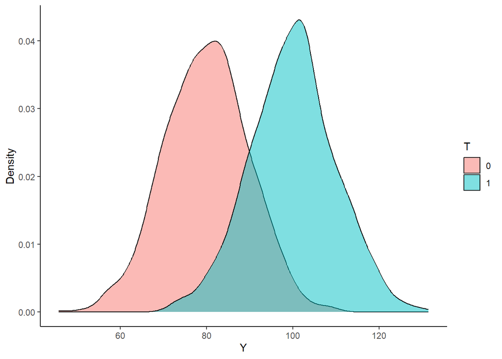

We can clearly see a difference and this should also manifest in estimation.

# Estimation

$$\begin{aligned} \tau &= \mathbb{E}[Y_i(1) - Y_i(0)]\\ &= \mathbb{E}[Y_i(1)] - \mathbb{E}[Y_i(0)]\\ &= 100 - 80 \end{aligned}$$

because these are the means of the two potential outcomes in our DGP.

## Regression

We can thus estimate the following regression equation: $Y_i = \alpha + \beta T_i + \epsilon_i$

```r
# Run a linear regression on the data to estimate the treatment effect
model <- lm(Y ~ T, data = data)

# Print the summary of the regression output
# Note: tab_model is a function from the sjPlot package for pretty printing of regression results
tab_model(model, show.stat = TRUE)
```

|  | Y |  |  |  |
| --- | --- | --- | --- | --- |
| Predictors | Estimates | CI | Statistic | p |
| (Intercept) | 79.93 | 79.33 – 80.53 | 261.95 | **<0.001** |
| T | 20.01 | 19.15 – 20.87 | 45.81 | **<0.001** |
| Observations | 2000 |  |  |  |
| R<sup>2</sup> / R<sup>2</sup> adjusted | 0.512 / 0.512 |  |  |  |

The regression model estimates the average treatment effect (ATE) as the difference between the mean outcomes in the treatment and control groups. We can interpret the coefficient $\hat{\beta}$ on the `T` variable as the estimated effect of the treatment on the outcome $\hat{\tau}$:

```
The estimated average treatment effect is 20.01 [ 19.15 20.87 ]
```

```
The true sample average treatement effect is 20.09
```

We can see that the estimated ATE from the regression is similar to the true ATE calculated from the potential outcomes.

## Alternative: t-test

In the case of randomized, independent groups, we can also use a simple two-sample t-test.

```r
t.result <- t.test(data$Y[data$T==1], data$Y[data$T==0], var.equal = TRUE)
t.result
```

```
    Two Sample t-test

data:  data$Y[data$T == 1] and data$Y[data$T == 0]
t = 45.81, df = 1998, p-value < 2.2e-16
alternative hypothesis: true difference in means is not equal to 0
95 percent confidence interval:
 19.15247 20.86566
sample estimates:
mean of x mean of y
 99.93661  79.92754
```

This provides the same results (i.e., same t-statistic) as the regression in this simple case.

*Note: That you have to specify equal (pooled) variance for the t.test, because the default in R is the Welch (or Satterthwaite) approximation for unequal variances for this function.*

# Including Covariates

Now, we want to extend the data generating process by including three independent covariates `X1`, `X2`, `X3`.

We can modify the previous data generating process code as follows:

```r
# Define the number of observations
n <- 2000

# Generate covariates
Age <- round(rnorm(n, mean = 50, sd = 10),0) # e.g., Age
Prev_Purch <- rpois(n, lambda = 5) # Count variable, e.g., previous purchases
Loyalty_card <- sample(c("Yes", "No"), size = n, replace = TRUE) # Nominal variable; e.g., loyalty card membership

# Convert Loyalty_card to a binary indicator
Loyalty_card <- ifelse(Loyalty_card == "Yes", 1, 0)

# Generate potential outcomes with covariates
Y1 <- E_y1 + 0.5*Age + 2*Prev_Purch - 10*Loyalty_card + rnorm(n, mean = 0, sd = 5)
Y0 <- E_y0 + 0.5*Age + 2*Prev_Purch - 10*Loyalty_card + rnorm(n, mean = 0, sd = 5)

# The true average treatment effect / causal effect
tau <- mean(Y1) - mean(Y0)

# Calculate the observed outcome based on treatment assignment
Y <- Y0 + (Y1-Y0)*T

# Create a data frame
data2 <- data.frame(T, Y, Y1, Y0, Age, Prev_Purch, Loyalty_card)

kable(head(data2))
```

| T | Y | Y1 | Y0 | Age | Prev_Purch | Loyalty_card |
| --- | --- | --- | --- | --- | --- | --- |
| 0 | 117.9874 | 122.9240 | 117.9874 | 37 | 3 | 0 |
| 0 | 118.0686 | 137.9788 | 118.0686 | 61 | 5 | 0 |
| 1 | 131.5213 | 131.5213 | 105.3014 | 57 | 4 | 1 |
| 1 | 137.2886 | 137.2886 | 116.2287 | 61 | 3 | 0 |
| 1 | 129.2158 | 129.2158 | 111.0710 | 46 | 3 | 0 |
| 0 | 119.2842 | 139.4615 | 119.2842 | 49 | 5 | 0 |

In this modified data generating process, we generate three independent covariates `Age`, `Prev_Purch`, and `Loyalty_card`. We then generate potential outcomes `Y1` and `Y0` using these covariates, where we assume a linear relationship between the outcomes and the covariates. The effect of the covariates on the two outcomes is the same (for now). Lastly, we calculate the observed outcome `Y` based on the treatment assignment `T` and combine all the variables into a data frame.

We now estimate the following regression equation: $Y_i = \alpha + \beta T_i + \gamma X_i + \epsilon_i$

```r
# Run a linear regression on the data to estimate the treatment effect
model2 <- lm(Y ~ T + Age + Prev_Purch + Loyalty_card, data = data2)

# Print the summary of the regression output
tab_model(model2)
```

|  | Y |  |  |
| --- | --- | --- | --- |
| Predictors | Estimates | CI | p |
| (Intercept) | 79.54 | 78.29 – 80.79 | **<0.001** |
| T | 20.22 | 19.77 – 20.66 | **<0.001** |
| Age | 0.51 | 0.49 – 0.53 | **<0.001** |
| Prev Purch | 1.96 | 1.85 – 2.06 | **<0.001** |
| Loyalty card | -10.16 | -10.61 – -9.72 | **<0.001** |
| Observations | 2000 |  |  |
| R<sup>2</sup> / R<sup>2</sup> adjusted | 0.871 / 0.871 |  |  |

```
The estimated treatment effect is 20.22 [ 19.77 20.66 ]
```

```
The true sample treatement effect is 20.21
```

We again get an estimate of the average treatment effect (ATE) close to the true value.

However, we should also get a similar outcome if we exclude the covariates and again only estimate $Y_i = \alpha + \beta T_i + \epsilon_i$

```r
# Run a linear regression on the data to estimate the treatment effect
model3 <- lm(Y ~ T, data = data2)

# Print the summary of the regression output
tab_model(model3)
```

|  | Y |  |  |
| --- | --- | --- | --- |
| Predictors | Estimates | CI | p |
| (Intercept) | 109.44 | 108.84 – 110.04 | **<0.001** |
| T | 20.19 | 19.33 – 21.05 | **<0.001** |
| Observations | 2000 |  |  |
| R<sup>2</sup> / R<sup>2</sup> adjusted | 0.514 / 0.514 |  |  |

```
The estimated treatment effect is 20.19 [ 19.33 21.05 ]
```

```
The true sample treatement effect is 20.21
```

The estimated treatment effect is more or less the same as without covariates. However, the more important observation is that we get larger standard errors (wider confidence intervals) without the covariates in this case.

# Conclusion

In this document, we discussed the potential outcomes framework and the concept of causal effects in form of average treatment effects (ATE). We defined the quantities observed within this framework and presented a data generating process (DGP) to illustrate the concepts. The generated dataset can be used for further analysis and exploration of causal effects, as illustrated based on a regression analysis of the data. We also extended the DGP to include additional independent covariates.